We’re going to need a little help installing iDigBio’s R library, so lets start there:

```r
install.packages("devtools")
library(devtools)
```

Now we can use the function install_github to install iDigBio’s R library and then load it into memory:

```r
install_github("idigbio/ridigbio")
library(ridigbio)
```

Let’s take a look at this month’s biodiversity spotlight, the fathead minnow, “pimephales promelas”, in iDigBio by creating a dataframe using the function idig_search_records:

```r
fatheadData <- idig_search_records(rq=list(scientificname="pimephales promelas"))
str(fatheadData)
```

```
## 'data.frame':    4463 obs. of  12 variables:
##  $ uuid          : chr  "0008d42b-d35d-495a-8f1a-85da16a56f95" "001c0813-9193-4587-845c-b1fa36c3a3a4" "00290af7-469f-4c19-880b-49578a7d2abd" "0037b666-62ce-4686-9cb4-71548dc1fbcf" ...
##  $ occurrenceid  : chr  "dca6d8ae-1ed3-11e3-bfac-90b11c41863e" "urn:lsid:biosci.ohio-state.edu:osuc_occurrences:osum__7449" "urn:occurrence:arctos:ucm:fish:7223:2540659" "http://biocoll.inhs.illinois.edu/fish/inhs832" ...
##  $ catalognumber : chr  "34424" "osum 7449" "7223" "832" ...
##  $ family        : chr  "cyprinidae" "cyprinidae" "cyprinidae" "cyprinidae" ...
##  $ genus         : chr  "pimephales" "pimephales" "pimephales" "pimephales" ...
##  $ scientificname: chr  "pimephales promelas" "pimephales promelas" "pimephales promelas" "pimephales promelas" ...
##  $ country       : chr  "united states" "united states" "united states" "united states" ...
##  $ stateprovince : chr  "kansas" "ohio" "colorado" "illinois" ...
##  $ geopoint.lat  : chr  "39.7361111" "41.5064" NA "41.48569" ...
##  $ geopoint.lon  : chr  "-101.8788889" "-83.0577" NA "-87.60199" ...
##  $ datecollected : chr  "2003-06-03T00:00:00+00:00" NA NA "1969-11-07T00:00:00+00:00" ...
##  $ collector     : chr  "kansas department of wildlife and parks" "daiber, f. c. (frank c.) & ryther, j. (john)" "collector(s): unknown" "p. vidal & j.w. sublett" ...
```

We can see that the data returned by the iDigBio search API contains these columns:

```r
colnames(fatheadData)
```

```
##  [1] "uuid"           "occurrenceid"   "catalognumber"  "family"
##  [5] "genus"          "scientificname" "country"        "stateprovince"
##  [9] "geopoint.lat"   "geopoint.lon"   "datecollected"  "collector"
```

For some sanity checking of the data, we can create a plot of the latitude and longitude of these records:

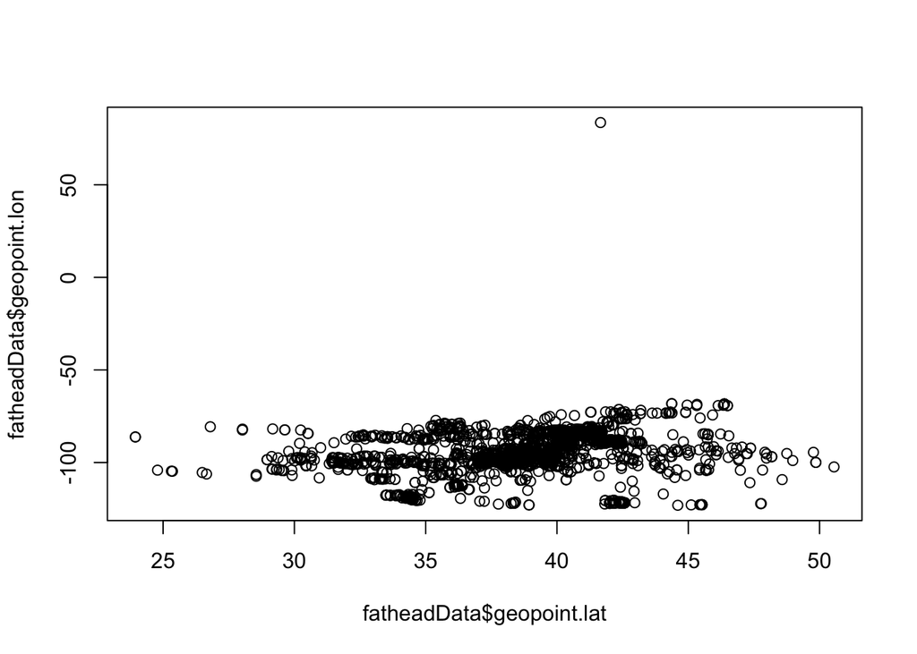

```r
plot(fatheadData$geopoint.lat,fatheadData$geopoint.lon)
```

And see what data is present in the “country” and “stateprovince” columns:

```r
unique(fatheadData$country)
```

```
## [1] "united states" "mexico"        "canada"        "nicaragua"
## [5] NA
```

```r
unique(fatheadData$stateprovince)
```

```
##  [1] "kansas"         "ohio"           "colorado"       "illinois"
##  [5] "massachusetts"  "pennsylvania"   "texas"          "california"
##  [9] "minnesota"      "oklahoma"       "tennessee"      "chihuahua"
## [13] "missouri"       "new york"       "new mexico"     "kentucky"
## [17] "indiana"        "south carolina" "wisconsin"      "wyoming"
## [21] "nebraska"       "saskatchewan"   "arizona"        "iowa"
## [25] "quebec"         "alabama"        "vermont"        "virginia"
## [29] "louisiana"      "florida"        "georgia"        "south dakota"
## [33] "oregon"         "michigan"       "alberta"        "maine"
## [37] "durango"        "north carolina" "utah"           "montana"
## [41] "new jersey"     "ontario"        "north dakota"   "connecticut"
## [45] "arkansas"       "west virginia"  "chinandega"     "delaware"
## [49] NA               "nevada"         "idaho"          "mississippi"
## [53] "washington"     "manitoba"       "new hampshire"  "maryland"
```

Looks like we have an outlier, lets take a closer look:

```r
outlier <- fatheadData[which(fatheadData$geopoint.lon >0),]
outlier$country
```

```
## [1] "united states"
```

Since we know that this outlier is an error in the data, we will create a new dataframe with this outlier omitted

```r
cleanedData <- fatheadData[which(fatheadData$uuid != outlier$uuid),]
```

Now let’s output this data to a CSV file so we can work with it in other applications

```r
write.csv(cleanedData, file="idigbio-fathead-data-yyyymmdd.csv",row.names=FALSE)
```

As an excercise for the reader, can you recreate the following map with the concepts presented above?

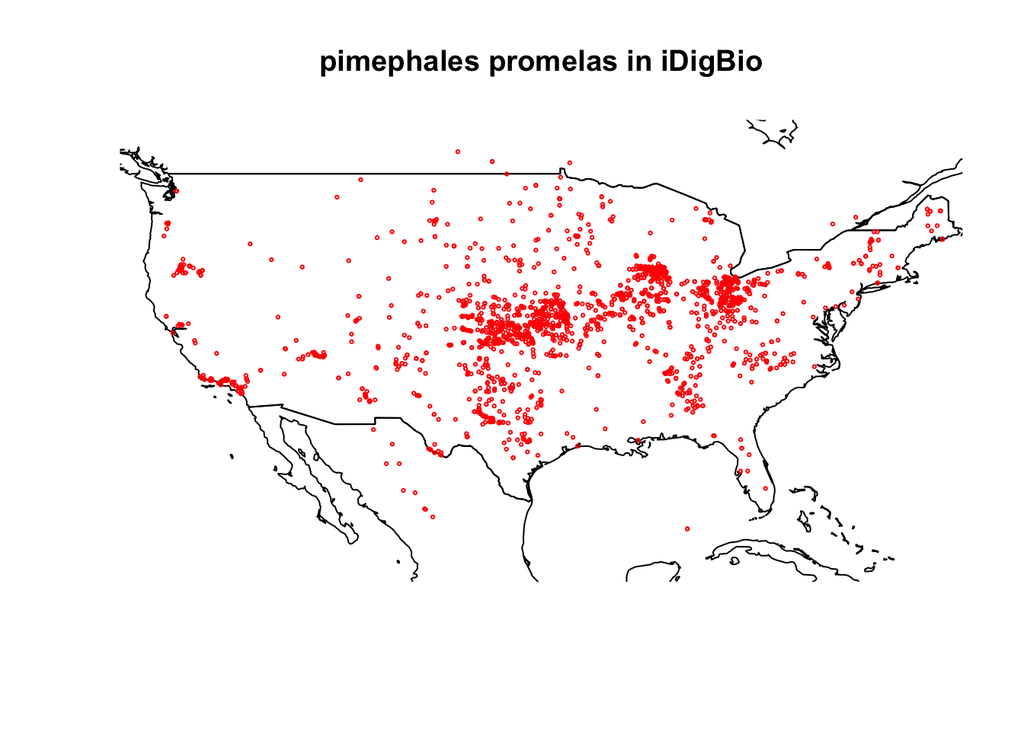